# R for Beginners

### Three Dimensional Plots

Three dimensional graphics are quite fashionable and good looking. Nevertheless, more technical two dimensions plots such as `trellis` graphics may help to understand graphics in better details.

R offers a wide variety of three dimensional graphics. Some not exaustive examples when representing a bivariate normal distribution are:

[figure not shown]

```r
library(mnormt)
mu = c(0,0)
sigma = matrix(c(1, 0, 0, 1), 2, 2)
x = seq(-3, 3, 0.1)
y = seq(-3, 3, 0.1)
f = function(x, y){dmnorm(cbind(x, y), mu, sigma)}
z = outer(x, y, f)

par(mfrow = c(2, 2))
persp(x, y ,z, theta = 30)
image(x, y, z)
contour(x, y, z)
image(x, y, z)
contour(x, y, z, add = T)
```

By using a different technique from the `lattice` package. The `lattice` package will be presented in the next Paragraph.

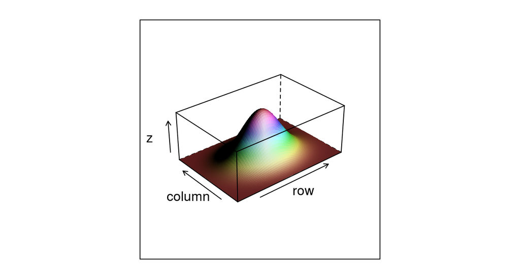

```r
library(lattice)
pl = wireframe(z, shade = TRUE, aspect = c(61/87, 0.4),
  light.source = c(10,0,10))
print(pl)
```

## Introduction to Alternative Graphic Systems

### `lattice` Graphics

`lattice` is an add-on package that implements Trellis graphics (originally developed for S and S-Plus) in R.

It is a powerful and elegant high-level data visualization system, with an emphasis on multivariate data, that is sufficient for typical graphics needs, and is also flexible enough to handle most nonstandard requirements.

A lattice display is usually takes two arguments:

- a formula object;
- a data frame.

Formulas are generally defined as: $y \sim x | f$ meaning to plot y versus x in a separate panel as defined by the level of factor f.

Plot customization is made by mean of the `panel` argument. Panel argument require a function, usually built by combining standard panel functions defined as part of the `lattice` package.

The `istat` dataset contains information about weight and height for females and males. The interests is in understanding in which proportion weight is explained by height and how this relatioship differs from females to males.

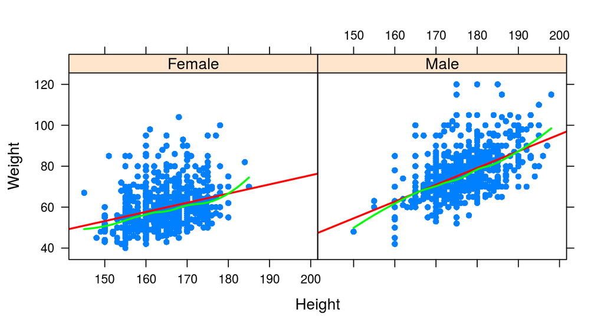

```r
library(lattice)
load("istat.Rda")
p = xyplot(Weight ~ Height | Gender, data = istat,
  panel = function(x, y , ...){
    panel.xyplot(x, y, pch = 16, ...)
    panel.lmline(x, y, col = "red", lwd = 2, ...)
    panel.loess(x, y, degree = 2, span = .5, col = "green", lwd = 2, ...)
  }
)
print(p)
```